# l11_es

Seminario de Investigación

Semana 11: Causalidad

Sergi Martínez

smsoler@clio.uc3m.es | Horario de tutorías: martes 10:00–13:00 (previo correo)

## Hoy

17 de noviembre

- Experimentos
  - Conjoint, de laboratorio y de campo
- Nuestra realidad y algunas alternativas
- Sesiones de asesoría de 5’
  - Comité ético
  - Feedback última entrega
  - Siguientes pasos

## Conjoint (de conjuntos de atributos): Si me das a elegir…

**Descripción**:

- A cada persona se le muestran perfiles (eventos, candidaturas, productos, políticas) formados por varios atributos.
- Los **niveles de cada atributo se asignan al azar**, de modo que ningún atributo queda correlacionado con otro.
- La persona elige entre perfiles o los puntúa. Cada participante repite la tarea varias veces.

**Pros**:

- Estima el **efecto causal de cada atributo** sobre la elección, gracias a la aleatorización.
- Permite **comparar la importancia relativa** de atributos muy distintos, por ejemplo, en el caso de candidatxs, la agenda política frente al origen étnico.
- Reduce el sesgo de deseabilidad social, porque no se pregunta directamente por el motivo de la elección.

**Para qué se utiliza**:

- Mercadotécnia: preferencia de consumidores por productos con distintos atributos

## Ejemplos clásicos en ciencia política

- El buen migrante
- El perfecto presidenciable:

[interactive chart not shown]

## Ejemplo: El valor de la democracia

*¿Cómo mediríais qué tipo de estado prefiere la gente?*

- Podemos utilizar los experimentos conjoints para observar qué dimensiones valoramos más de nuestros estados:

[interactive chart not shown]

## Ejemplo: El valor de la democracia (II)

[interactive chart not shown]

## Limitaciones de los conjoint

- Hay combinaciones de atributos que dan perfiles poco realistas
- Forzar elegir da lugar, habitualmente a inconsistencias que no se reproducen en comportamientos

**Experimentos de laboratorio**

**Definición**: los participantes acuden a un *entorno controlado* (un laboratorio o aula) donde el investigador manipula una variable, asigna al azar a los sujetos a las condiciones y mide las reacciones de forma inmediata [pensad que antes las encuestas no se realizaban online]

- **Qué se manipula**: un estímulo concreto, como un panfleto editado, un mensaje político, un anuncio de campaña o las reglas de un juego de negociación o de bienes públicos
- **Qué se mide**: actitudes, decisiones o conductas durante la sesión, a veces con instrumentos que no existen en una encuesta (tiempos de respuesta, seguimiento ocular, juegos con pagos reales)

**Pros**

- **Control del entorno**: mismas condiciones, solo cambia lo que manipulamos -> **validez interna** (causalidad)
- **Mecanismos**: podemos medir los pasos intermedios (atención, recuerdo, argumentos en contra) y no solo el resultado final
- **Tratamientos que no existen en la vida real**: podemos crear el estímulo exacto que la teoría exige y mantener constante todo lo demás
- **Coste moderado**+

## Ejemplo: Milgram

[video not shown]

## Ejemplo: Baldassarri y Grossman

[interactive chart not shown]

## Ejemplo: Gilligan, Samii, Pasquale

[interactive chart not shown]

## Limitaciones

**De las encuestas, en general**

- Las encuestas raramente capturan comportamientos reales, y las decisiones hipotéticas pueden diferir de las reales.
- Los tratamientos de encuesta suelen ser débiles y poco realistas:
  - Estamos expuestos a miles de mensajes de ese tipo a lo largo del día
  - Distan de ser experiencias reales [*baja validez externa*]

## Ejemplo: Barabas y Jerit

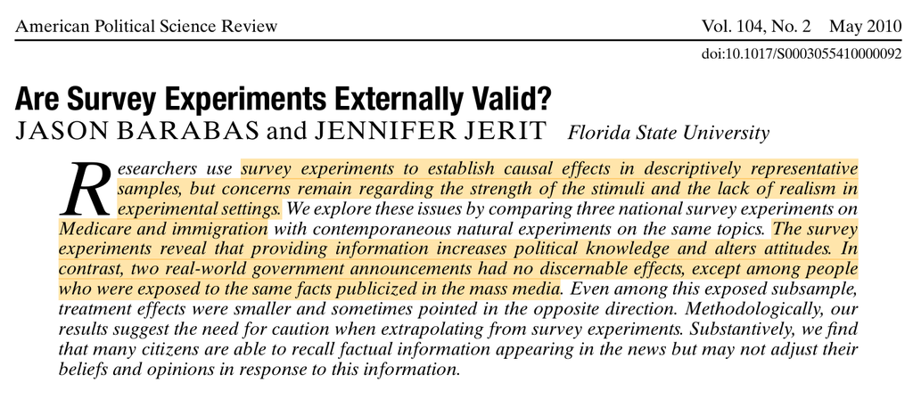

## La “solución”

El *jamón de jabugo* de las CCSS: los **Experimentos controlados aleatorios de campo**

- Entre los miembros de muestra, se controla y aleatoriza su presencia o exposición a un evento, una experiencia, oun proceso que ocurre en la vida real: *La aleatorización* no se da en laboratorios o encuestas, sino *en situaciones del día a día*
- Ejemplos habituales: Campañas de canvassing o get-out-the-vote (GOTV) en elecciones, experimentos de educación, experimentos de salud pública, etc.

## Experimentos de campo (randomized controlled trials)

Método de donde el investigador manipula una variable independiente (como el envío de información electoral, una política pública o un incentivo) en un entorno real y cotidiano, con el fin de medir su efecto causal sobre el comportamiento de los ciudadanos, líderes o instituciones.

- Entorno natural del tratamiento: Se desarrollan fuera del laboratorio, en la vida real.
  - Aleatorización (randomization): Los sujetos o unidades de estudio (individuos, vecindarios, mesas electorales) se dividen al azar en grupo de tratamiento (reciben el estímulo) y grupo de control (no lo reciben).
  - Inferencia causal: Permiten aislar relaciones de causa y efecto con gran validez externa, ya que ocurren en condiciones reales.
- Medir los outcomes/variable dependiente con encuestas, con datos administrativos de comportamientos o decisiones, etc

## Ejemplo

[figure not shown]

## Cilliers et al. (2016): argumento y caso

**Argumento.** Tras un conflicto, los foros comunitarios de reconciliación aumentan el perdón, las redes sociales y las contribuciones a bienes públicos, pero empeoran la salud mental.

**Caso: Sierra Leona**

Guerra civil de 1991 a 2002, con más de 50.000 muertos y 2,6 millones de desplazados

**Intervención: Fambul Tok**

ONG local. Las víctimas relatan, los perpetradores confiesan sin castigo y hay una hoguera de 2 días

**Diseño**

Ensayo aleatorizado con 100 secciones, 200 pueblos y 2383 encuestados, medidos hasta 31 meses después

## Cilliers et al. (2016): diseño experimental

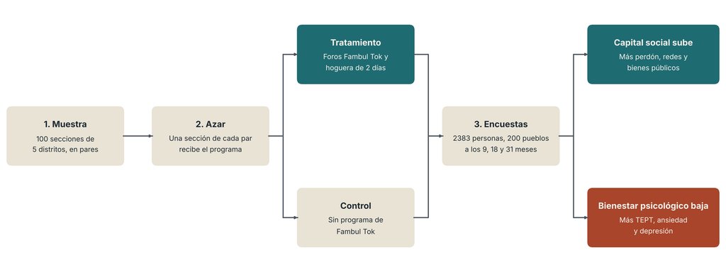

## Cilliers et al. (2016): resultados

Más capital social, pero más estrés postraumático clínico (+36% frente al 8% del control). Los efectos persisten a los 31 meses.

| Resultado | Efecto | Error est. |
| --- | --- | --- |
| Perdón a perpetradores | +0,571** | (0,227) |
| Confianza en excombatientes | +0,177** | (0,079) |
| Redes sociales | +0,099*** | (0,028) |
| Participación comunitaria | +0,058*** | (0,017) |
| Bienes públicos | +0,042* | (0,022) |
| Confianza generalizada | +0,006 | (0,027) |
| Bienestar psicológico | −0,147*** | (0,033) |
| TEPT clínico (probabilidad) | +0,029*** | (0,011) |

Errores estándar entre paréntesis, agrupados por sección. *** p<0,01, ** p<0,05, * p<0,1. En bienestar, un valor negativo indica peor salud mental.

## Otro ejemplo: Balcells et al. (2021)

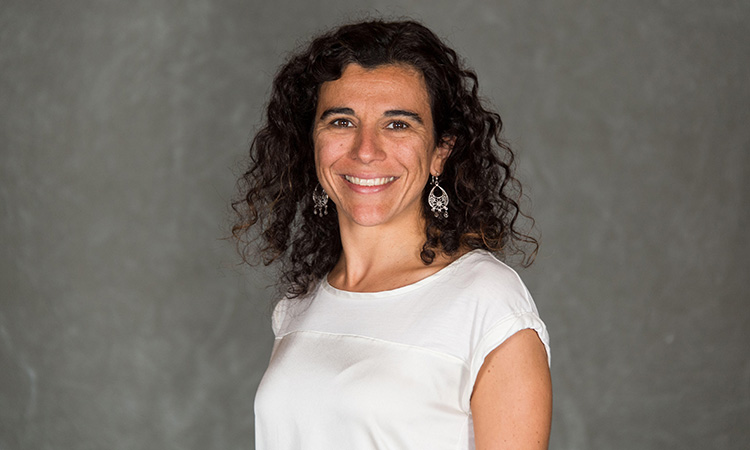

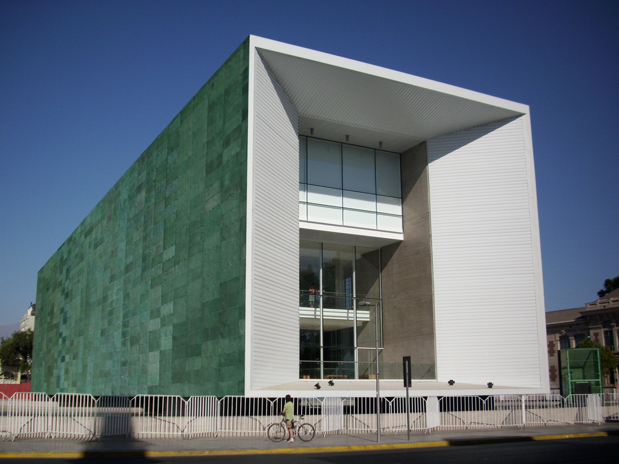

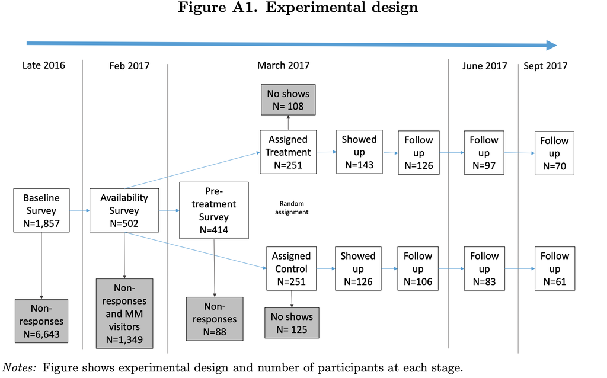

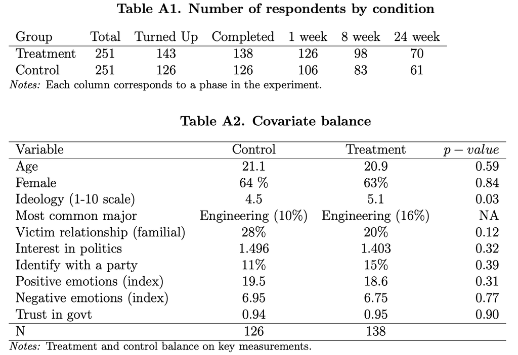

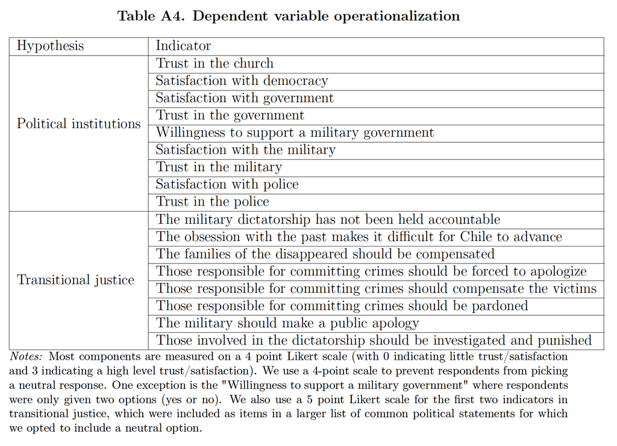

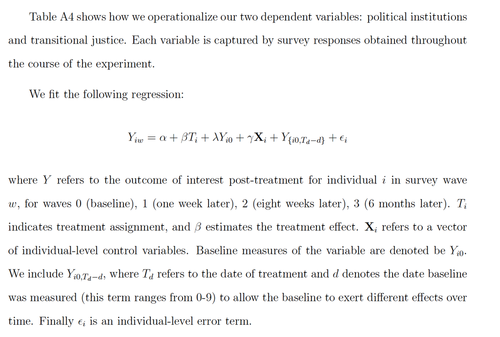

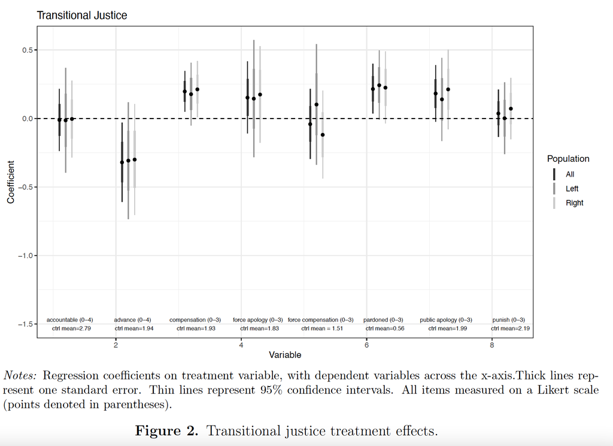

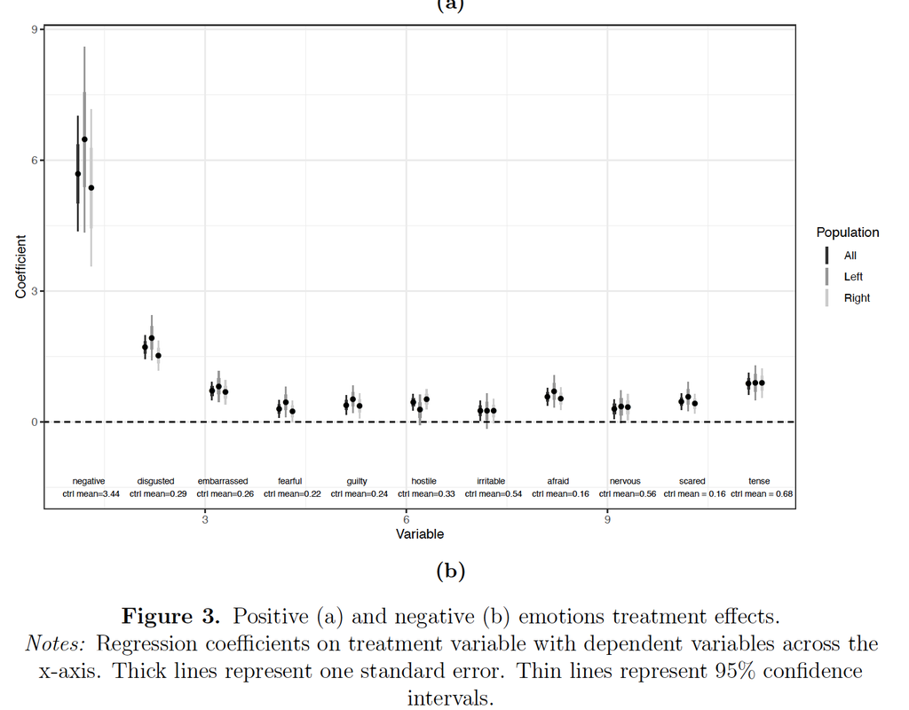

## Ejemplo: experimentos de campo

Pregunta: ¿Cómo afectan las políticas de memoria a la opinión pública?

Contexto: En Madrid

[figure not shown]

[figure not shown]

## Los distintos tipos de exp no son excluyentes

- momentos histórios
- actores
- enfoques
- contenidos
- narrativas

Quizá sería interesante plantear un ejercicio así en ESP para identificar los consensos y tratar de construir en base a ellos

## Ejemplo: Mousa (2020)

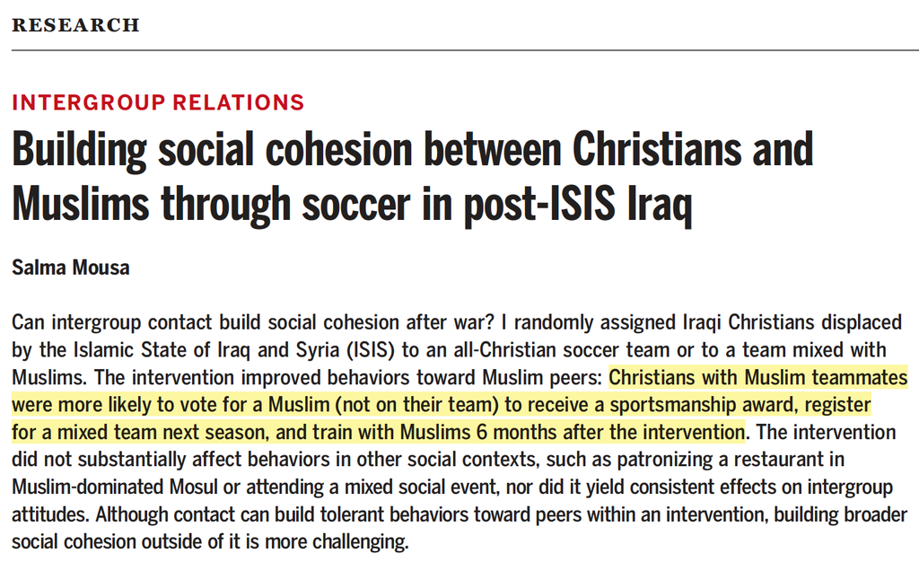

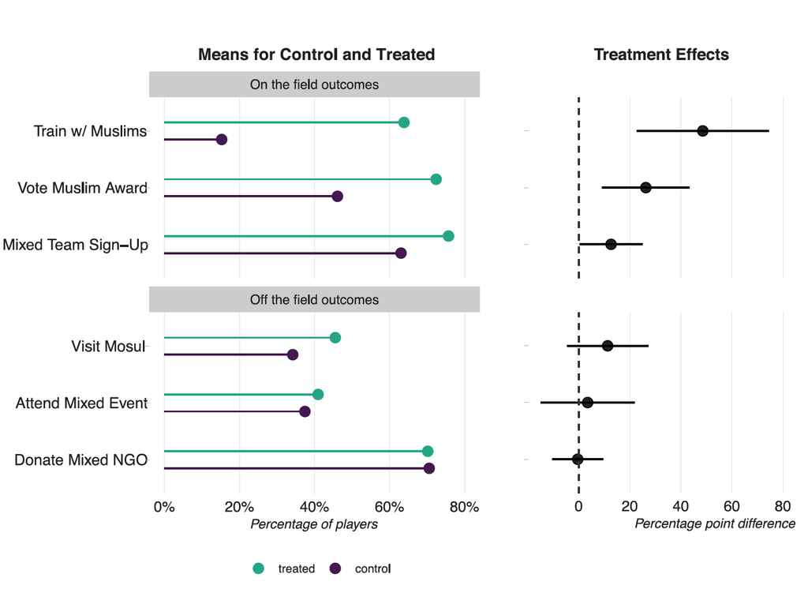

## Pensemos en nuestros trabajos

1. Caso de estudio:
   - Marco temporal y geográfico
   - Social, economic, and political context
2. Estrategia de investigación cualitativa
3. Estrategia de investigación cuantitativa:
- *‘Can we randomize our independent variable?’* Who would be part of the ‘treated’ and the control groups?
- At what level would we measure our dependent variable? Through which measurement instrument?

## Otro ejemplo de discriminación

¿Cómo mediríais discriminación en el día a día?

- Pista: Pensad en un posible experimento de campo

Tres grupos:

- [G1](https://www.dropbox.com/scl/fi/dl5ra9qub0qvdw7we74zn/L11_G1.pdf?rlkey=4n2i59toas1yc0crps37its7c&st=oerbmvvx&dl=0)
- [G2](https://www.dropbox.com/scl/fi/72jwdoa2jn28i9rfqpiyr/L11_G2.pdf?rlkey=lb73zok3za3tzi2mjqetmpbgv&st=mpqv2590&dl=0)
- [G3](https://www.dropbox.com/scl/fi/gpbcnc2r0paer9vb7gvb4/L11_G3.pdf?rlkey=0uy8jbpqh6o7wkb1pml1x5clb&st=6nk8w100&dl=0)

Cada grupo lee su parte y lo ponemos en común de manera crítica:

1. Resumen de esa parte (2-3’)
2. Qué preguntas tenéis sobre esa parte, qué echáis en falta y qué creéis que no tiene sentido (1-2’)
3. Discutamos las limitaciones y riesgos de este artículo

## ¡Nos vemos el próximo martes! Cualquier duda a smsoler@clio.uc3m.es